# Report: Citi Bike bike rentals

```r
# 2. Preparing data for visualisations/analyses

#loading in Libraries
library(tidyverse)
library(tsibble)
library(tsibbledata)
library(skimr)
library(lubridate)
library(ggplot2)
library(leaflet)

# cleaning/wrangling dataset
# preparing various datasets used for the plots

# 1. add multiple columns to group per time period:
nyc_bikes_dates <- nyc_bikes %>%
  mutate(year = year(start_time),
         month = month(start_time, label = TRUE, abbr = TRUE),
         day = day(start_time),
         weekday = wday(start_time, label = TRUE, abbr = TRUE))

# 2. add age groups:
# let's add age to the dataset, and divide per age group
  # 0-17, 18-25, 26-35, 35-50, 50-65, 66-up
nyc_bikes_dates_age <- nyc_bikes_dates %>%
    mutate(age = 2018 - birth_year) %>%
  mutate(age_group = case_when(
    age < 18 ~ "0-17",
    age >= 18 & age <= 25 ~ "18-25",
    age > 25 & age <= 35 ~ "26-35",
    age > 35 & age <= 50 ~ "36-50",
    age > 50 & age <= 65 ~ "50-65",
    age > 65 ~ "66-up"
  ))

# 3. reformat the tsibble into tibble to get some calculations
gender_calc <- as.tibble(nyc_bikes_dates)
```

# 1. Documentation - introduction

### About the company

“Citi Bike” is a bike rental company in New York City launched in 2013. Bikes can be rented from docking stations across a network of bike stations throughout the city. Bikes can be returned at any station of choice.

For regular customers bike hire prices are fixed for 30 minutes, with a fixed amount per minute after. People with a subscription get the first 45 minutes per day for free.

**Current level of bike rentals**  
In 2018 we have seen a total of 4268 bikes being rented

```r
nyc_bikes_dates %>%
  index_by(year) %>%
  summarise(total_rentals = n())
```

| year | total_rentals |
| --- | --- |
| 2018 | 4268 |

**Area of activity**  
Citi Bike is currently available and active in the Jersey City area. The following map shows the location of users renting bikes in 2018.

```r
leaflet(nyc_bikes) %>%
  addTiles() %>%
  addCircleMarkers(
    lng = ~ start_long,
    lat = ~ start_lat,
    clusterOptions = markerClusterOptions()
  )
```

[interactive chart not shown]

*Description of visualisation*  
This map shows the geographical spread of starting positions of bike rentals of Citi Bike bikes. Based on this plot we see that highest popularity for bike hires is in Jersey City. By zooming in we see that the Christopher Columbus Drive station is the most popular station to rent a Citi Bike.  
*Importance*  
This map is of importance to the business as it shows most popular areas to rent bikes which can be used by the operational team to assure sufficient availability of bikes at popular stations.

### Aim of this report

This report aims to provide insight into “Citi Bike’s” Key Performance Indicators by focussing on peak rental periods and customer base. The analysis provides information about peak rental periods: moments in time when bikes are most popular to rent.  
Further, customer demographics are analysed providing information about the type/group of customers interested in bike hires.

This will provide actionable insights as it gives information about periods in time when bike hires are low and customer groups that are less likely to hire bikes, based on the 2018 dataset.

In short, this report tries to answer the question:

**To who and when do we need to address our campaigns in order to increase our bike hires?**

The conclusions drawn from this report can be used by the commercial/advertisement team to focus on customers that are currently not regularly using bike rentals. Furthermore, Citi Bike’s future campaigns should focus on popularizing bike rentals at times we currently see low bike rental popularity.

### Ethics

Important to highlight is that data ethics have been taken into consideration during the analyses of the data.

- All data is anonymised and cannot be traced back to individual customers;
- We have further looked at underrepresented groups among the customers.

# 3. Data visualisation - analysis

### When are Citi Bike’s being hired?

We have focused on analysing the peak and off-peak periods for popularity of bike hires.  
Increasing bike hires can be achieved by focusing on popularising these off-peak periods, e.g. by advertisements and/or discount rates.

We have focussed on the following periods in time:

- Year and seasons
- Days
- Hours

#### Year and seasons

By plotting the total number of bike hires throughout the year per month, we can identify periods of low popularity.

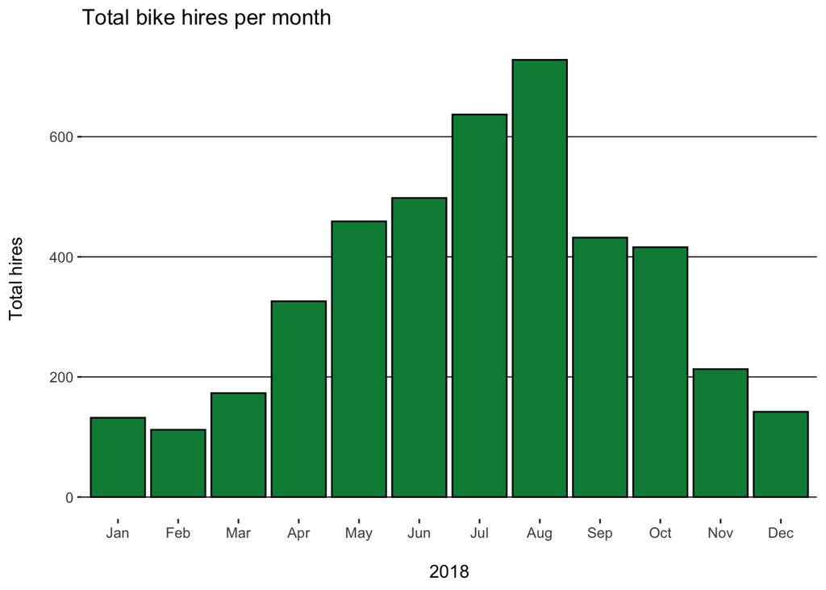

```r
nyc_bikes_dates %>%
  index_by(month) %>%
  summarise(rental_per_month = n()) %>%
  ggplot() +
  aes(x = month, y = rental_per_month) +
  geom_col(col = "black", fill = "springgreen4") +
  ggtitle("Total bike hires per month") +
  ylab("Total hires\n") +
  xlab("\n2018") +
  theme(panel.grid.major.x = element_blank(),
              panel.grid.minor.x = element_blank(),
        panel.background = element_blank(),
        panel.grid.major.y = element_line(size = 0.3, colour = "black"))
```

*Description of visualisation*  
This bar plot shows the number of bike hires per month in 2018. We can see that bike hires peak in August with over 700 bike hires, while the lowest number of bikes are rented in February with just over 100 bike hires.

*Importance*  
It is important to know which month’s are least popular for bike rentals because the commercial/advertisement team should focus on the least popular months to attract more customers. Further, the customer team can focus on the most busy months in terms of improving customer experience in successful months in order not to loose customers due to heavy demands.

The above graph indicates that bike rental popularity is likely linked to weather conditions. This is clearer when we divide the rental data per season:

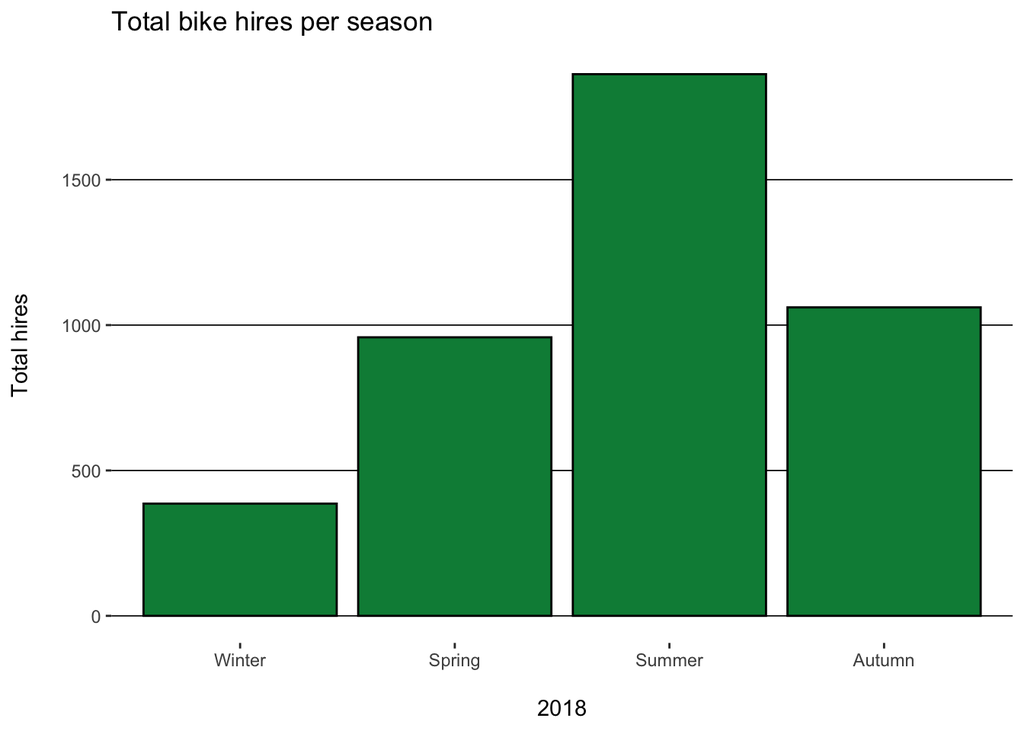

```r
# lets check per season, with (Dec, Jan, Feb = Winter); (Mar, Apr, May = Spring); (Jun, Jul, Aug = Summer); (Sep, Okt, Nov: Autumn)
nyc_bikes_dates %>%
  mutate(season = recode(month,
                        "Jan" = "Winter",
                        "Feb" = "Winter",
                        "Mar" = "Spring",
                        "Apr" = "Spring",
                        "May" = "Spring",
                        "Jun" = "Summer",
                        "Jul" = "Summer",
                        "Aug" = "Summer",
                        "Sep" = "Autumn",
                        "Oct" = "Autumn",
                        "Nov" = "Autumn",
                        "Dec" = "Winter")) %>%
  index_by(season) %>%
  summarise(rental_per_season = n()) %>%
  ggplot() +
  aes(x = season, y = rental_per_season) +
  geom_col(col = "black", fill = "springgreen4") +
  theme(panel.grid.major.x = element_blank(),
        panel.grid.minor.x = element_blank(),
        panel.background = element_blank(),
        panel.grid.major.y = element_line(size = 0.3, colour = "black")) +
  ggtitle("Total bike hires per season") +
  ylab("Total hires\n") +
  xlab("\n2018")
```

*Description of visualisation*  
This bar plot shows the number of bike hires per season in 2018. We can see that bike hires peak during the Summer with over 1750 bike hires, while the lowest number of bikes are rented during Winter with less than 500 bike hires.

*Importance*  
This graph is clearly indicating the most popular seasons for bike hires. It might be a good idea for the commercial team to increase visibility of advertisements during seasons of low popularity in order to attract more customers and increase bike rentals.  
Based on the per-month plot we suggested that in seasons with nice weather rental numbers peak. However, in spring we generally see better weather than in autumn and still rental numbers in Spring are second lowest. This can be a great opportunity for the advertisement team to focus on!

#### Days and hours

When we look at most popular days for bike rentals we clearly see that working days are more popular than the weekends.

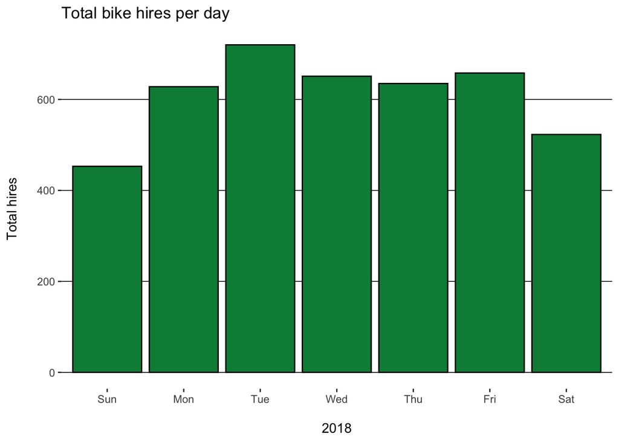

```r
nyc_bikes_dates %>%
  index_by(weekday) %>%
  summarise(rental_per_weekday = n()) %>%
  ggplot() +
  aes(x = weekday, y = rental_per_weekday) +
  geom_col(col = "black", fill = "springgreen4") +
  theme(panel.grid.major.x = element_blank(),
        panel.grid.minor.x = element_blank(),
        panel.background = element_blank(),
        panel.grid.major.y = element_line(size = 0.3, colour = "black")) +
  ggtitle("Total bike hires per day") +
  ylab("Total hires\n") +
  xlab("\n2018")
```

*Description of visualisation*  
This bar plot shows the total number of bike hires per weekday in 2018. We can see that bike hires are most popular on Tuesdays with over 700 bike hires, while the lowest number of bikes are rented on Sundays with ~450 bike hires.

*Importance*  
For the bike rental company it is important to know which day’s are least popular for bike rentals because the commercial/advertisement team could focus on the least popular days to attract more customers. Interestingly, most popular day to rent a bike is on a weekday while the least popular day is a day in the weekend! A great focus could be to advertise weekend activities, like sightseeing trips, per bike.  
Bike hires are not equally divided during the week. What are off-peak times during the day?

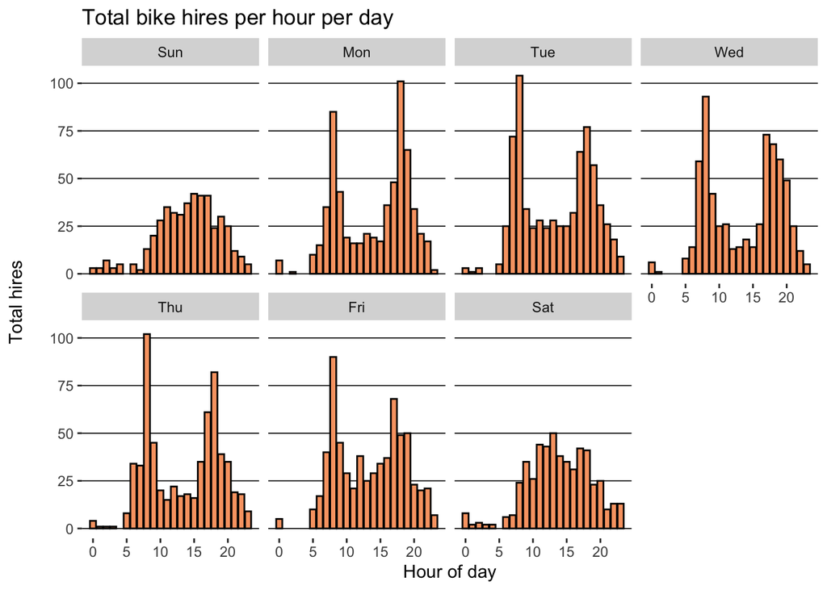

```r
nyc_bikes_dates %>%
  mutate(hour = hour(start_time)) %>%
  ggplot() +
  aes(x = hour) +
  geom_bar(col = "black", fill = "#F9A472") +
  facet_wrap(~weekday, ncol =4) +
  theme(panel.grid.major.x = element_blank(),
        panel.grid.minor.x = element_blank(),
        panel.background = element_blank(),
        panel.grid.major.y = element_line(size = 0.3, colour = "black")) +
  ggtitle("Total bike hires per hour per day") +
  ylab("Total hires\n") +
  xlab("Hour of day")
```

*Description of visualisation*  
This bar plot shows the total number of bike hires per weekday split per start time (in hours). We can see that bike hires are most popular during rush hour on weekdays. While Saturday and Sunday show a more unimodal distribution of bike rental popularity during the day.

*Importance*  
This barplot provides insights into peak and off-peak hours for bike hires throughout the day. For the operational team it is of importance to have as much bikes available as possible during rush hours. For the advertisement team it is important to realise that it might be smart to focus on tourists during the day to increase hires.

We have looked at when rental bikes are most popular in order for the advertisement team to know which off-peak periods should be advertised in order to attract more customers and increase bike hires. Furthermore, the peak periods are informative for the operational team to have plenty of bikes ready to rent out.

### Who is hiring Citi Bike’s?

We have analysed the demographics of customers renting bikes at Citi Bike.

We have focussed on the following demographics:

- Gender
- Age groups
- Trip types

#### Gender

We have first analysed the proportion of gender types renting bikes at Citi Bike:

```r
gender_calc %>%
  group_by(gender) %>%
  summarise(proportion_gender_types = n()/nrow(gender_calc))
```

| gender | proportion_gender_types |
| --- | --- |
| Unknown | 0.06302718 |
| Male | 0.71907216 |
| Female | 0.21790066 |

This indicates that bike hires are most popular among males than females. In fact, bike hires are more than double as popular to rent by males than females.  
*Importance*  
Firstly, it is of importance for a company to know what the customer base looks like. This can help in finding better tailered solution for client-specific wishes, or help in decisions to expand and increase attractivity of the product for under-represented groups. Furthermore, the big difference in male/female ratio interested in renting bikes should be investigated further by the customer team: The underlying cause could namely be that females feel unsafe renting a bike, this needs to be addressed and investigated further!

When we plot our daily bike rental plot and divide per gender we see that males are actually causing the workday/business day difference. While bike usage among females are stable across the week:

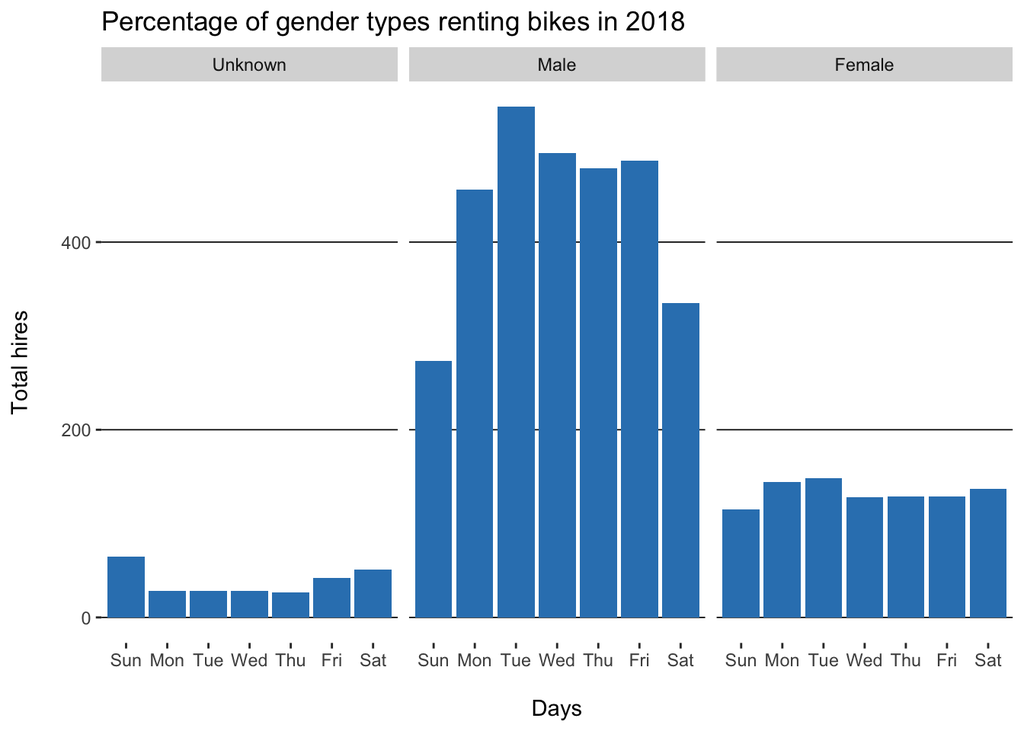

```r
nyc_bikes_dates %>%
  ggplot() +
  aes(x = weekday) +
  geom_bar(fill = "#3182bd") +
  facet_wrap(~ gender) +
  xlab("\nDays") +
  ylab("Total hires\n") +
  ggtitle("Percentage of gender types renting bikes in 2018") +
  theme(panel.grid.major.x = element_blank(),
        panel.grid.minor.x = element_blank(),
        panel.background = element_blank(),
        panel.grid.major.y = element_line(size = 0.3, colour = "black"))
```

*Description of visualisation*  
This bar plot shows the total number of bike hires per weekday in 2018, divided per gender. We can see that bike hires are most popular among males than females. For females there is hardly a difference in bike rentals between days. The pattern visible here (males with clear distinction between workday and weekend) indicates that males potentially use bikes to commute to work. While this is absent in females.

*Importance*  
Based on this plot we can conclude that the difference in bike rental popularity between weekdays and the weekend can be explained by males having a larger interest in renting bikes during workdays. The fact that this difference is absent in females indicates that women do not use bike hires for work commutes. This is a good opportunity for the advertisement/sales department to promote in order to increase overall bike hires.

#### Age groups

Besides gender we have looked at the age groups making use of Citi Bike, bike rental:

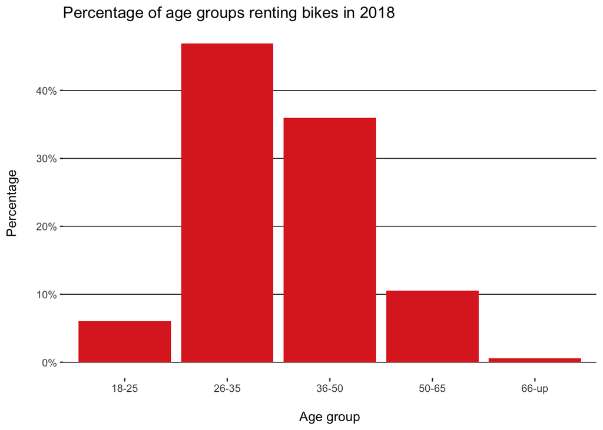

```r
nyc_bikes_dates_age %>%
  ggplot() +
  aes(x = age_group, y = after_stat(prop), group = 1) +
  geom_bar(fill = "#de2d26") +
  xlab("\nAge group") +
  ylab("Percentage\n") +
  ggtitle("Percentage of age groups renting bikes in 2018") +
  scale_y_continuous(labels = scales::percent_format()) +
  theme(panel.grid.major.x = element_blank(),
        panel.grid.minor.x = element_blank(),
        panel.background = element_blank(),
        panel.grid.major.y = element_line(size = 0.3, colour = "black"))
```

*Description of visualisation*  
This bar plot shows the proportion of age groups making use of Citi Bike rentals. Age groups have been created based on setting age boundaries between different generations. We see that the highest percentage of users are millenials aged between 26-35, followed by 36-50 year old’s. Young adults (aged 18-25) and older generations (50 and up) only form less than 20% of the total customer base.

*Importance*  
This information is important for the commercial/advertisement team to know: bike rental numbers can be increased if we promote bike rentals among the youth and elderly. This can potentially be reached by an add campaign.

#### Trip length as indication for user type

Finally, we have looked at trip length of bike rentals. We have filtered on trips less than one hour (taking out single outliers longer than one hour).

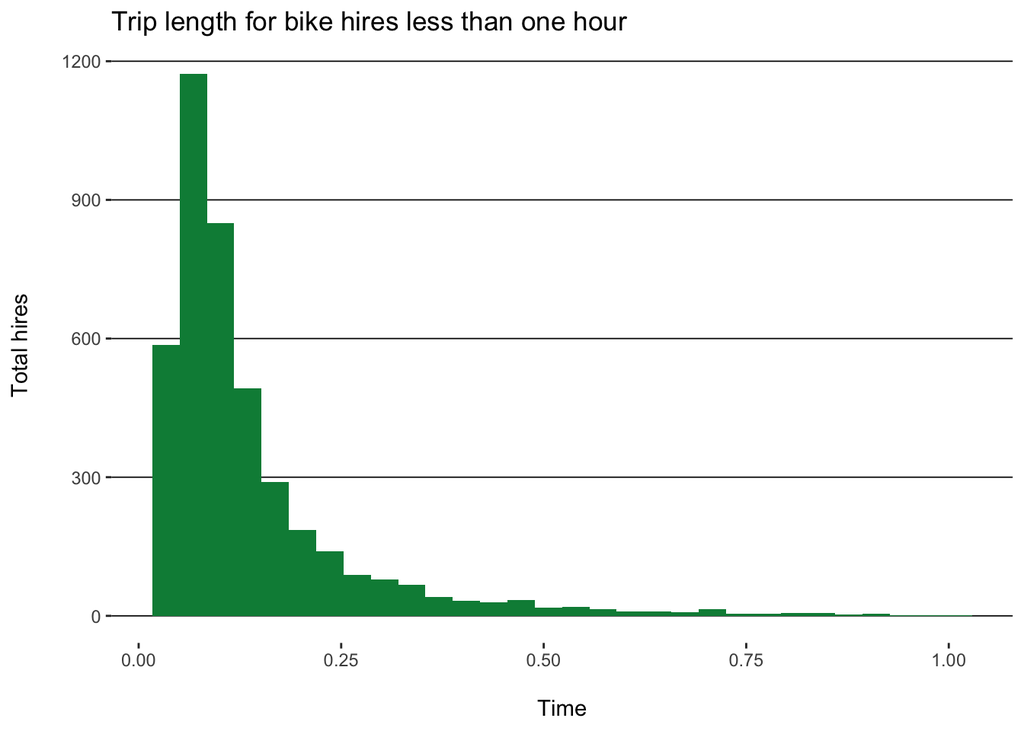

```r
nyc_bikes_dates_age %>%
  mutate(trip_time = stop_time - start_time) %>%
  mutate(time_hours = as.numeric(trip_time, "hours")) %>%
  filter(time_hours <= 1) %>%
  ggplot() +
  aes(x = time_hours) +
  geom_histogram(fill = "springgreen4") +
  theme(panel.grid.major.x = element_blank(),
        panel.grid.minor.x = element_blank(),
        panel.background = element_blank(),
        panel.grid.major.y = element_line(size = 0.3, colour = "black")) +
  ggtitle("Trip length for bike hires less than one hour") +
  ylab("Total hires\n") +
  xlab("\nTime")
```

*Importance*  
This information is very useful and confirms that having a fixed amount to be payed for a longer trip than the average trip length is a commercial attractive model as it generates more revenue than when charged for every minute. Further, it is adviced to increase popularity of longer trips (more than 30 minutes) as we see that only few people are using bikes for longer trip and with a per-minute rate every additional minute spend on a bike creates more revenue.

## Conclusions / key points

In this report we have focussed on peak rental periods and identified the main customers of Citi Bike bike rental.

In order to address the main objective: increasing total bike hires, we have aimed to answer:

**To who and when do we need to address our campaigns in order to increase our bike hires?**

We advice to increase visibility of Citi Bike to those customer groups that are currently underrepresented among rental bike users. Further, we advice to promote the use of bike rentals at off-peak periods as identified.